# group_project_report

## GROUP 135 PROJECT PROPOSAL

Group Members: Jannah Mohamed, Kate Saychaleun, Julia Toito, Elaine Chen

```r
library(tidyverse)
library(readxl)
library(ggplot2)
library(tidymodels)
```

```r
set.seed(2022)

download.file(url = "https://archive.ics.uci.edu/ml/machine-learning-databases/00257/Data_User_Modeling_Dataset_Hamdi%20Tolga%20KAHRAMAN.xls", destfile = "Data_User_Modeling_Dataset_Hamdi Tolga KAHRAMAN.xls")
```

```r
user_training_data <- read_excel("Data_User_Modeling_Dataset_Hamdi Tolga KAHRAMAN.xls", "Training_Data")%>%
    select(STG:UNS)
user_training_data["UNS"][user_training_data["UNS"] == "very_low"] <- "Very Low"
```

```r
user_test_data <- read_excel("Data_User_Modeling_Dataset_Hamdi Tolga KAHRAMAN.xls", "Test_Data")%>%
    select(STG:UNS)
```

```r
# tallying up the amount of each category of UNS
tally <- user_training_data %>%
    group_by(UNS) %>%
    summarize(amount = n()) %>%
    arrange(c(4, 2, 3, 1))

# mean of each one of the predictor variable
means <- user_training_data %>%
    select(-UNS) %>%
    map_df(mean)
```

```r
pvl1 <- user_training_data %>%
    ggplot(aes(x = STG, y = UNS, fill = UNS)) +
    geom_boxplot() +
    ylab("UNS (The Knowledge Level Of User)") +
    xlab("STG (The Degree of Study Time for Goal Object Materials)") +
    scale_y_discrete(limits = c("very_low", "Low", "Middle", "High")) +
    ggtitle("The Knowledge Level Of a User \nDepending on their Degree of Study Time for Goal Object Materials") +
    theme(text = element_text(size = 14))

pvl2 <- user_training_data %>%
    ggplot(aes(x = SCG, y = UNS, fill = UNS)) +
    geom_boxplot() +
    ylab("UNS (The Knowledge Level Of User)") +
    xlab("SCG (The Degree of Repetition Number of User for Goal Object Materials)") +
    scale_y_discrete(limits = c("very_low", "Low", "Middle", "High")) +
    ggtitle("The Knowledge Level Of a User \nDepending on their Degree of Repetition Number of User for Goal Object Materials") +
    theme(text = element_text(size = 14))

pvl3 <- user_training_data %>%
    ggplot(aes(x = STR, y = UNS, fill = UNS)) +
    geom_boxplot() +
    ylab("UNS (The Knowledge Level Of User)") +
    xlab("STR (The Degree of Study Time of User for Related Objects with Goal Object)") +
    scale_y_discrete(limits = c("very_low", "Low", "Middle", "High")) +
    ggtitle("The Knowledge Level Of a User \nDepending on their Degree of Study Time of User for Related Objects with Goal Object")+
    theme(text = element_text(size = 14))

pvl4 <- user_training_data %>%
    ggplot(aes(x = LPR, y = UNS, fill = UNS)) +
    geom_boxplot() +
    ylab("UNS (The Knowledge Level Of User)") +
    xlab("LPR (The Exam Performance of User for Related Objects with Goal Object)") +
    scale_y_discrete(limits = c("very_low", "Low", "Middle", "High")) +
    ggtitle("The Knowledge Level Of a User \nDepending on their Exam Performance of User for Related Objects with Goal Object") +
    theme(text = element_text(size = 14))

pvl5 <- user_training_data %>%
    ggplot(aes(x = PEG, y = UNS, fill = UNS)) +
    geom_boxplot() +
    ylab("UNS (The Knowledge Level Of User)") +
    xlab("PEG (The Exam Performance of User for Goal Objects)") +
    scale_y_discrete(limits = c("very_low", "Low", "Middle", "High")) +
    ggtitle("The Knowledge Level Of a User \nDepending on their Exam Performance of User for Goal Objects") +
    theme(text = element_text(size = 14))
```

```r
# performing forward selection
names <- colnames(user_training_data |> select(-UNS))
accuracies <- tibble(size = integer(),
                     model_string = character(),
                     accuracy = numeric())

knn_spec <- nearest_neighbor(weight_func = "rectangular",
                             neighbors = tune()) |>
     set_engine("kknn") |>
     set_mode("classification")

cancer_vfold <- vfold_cv(user_training_data, v = 5, strata = UNS)

n_total <- length(names)

selected <- c()

for (i in 1:n_total) {
    accs <- list()
    models <- list()
    for (j in 1:length(names)) {
        preds_new <- c(selected, names[[j]])
        model_string <- paste("UNS", "~", paste(preds_new, collapse="+"))

        # create a recipe from the model string
        cancer_recipe <- recipe(as.formula(model_string),
                                data = user_training_data) |>
                          step_scale(all_predictors()) |>
                          step_center(all_predictors())

        # tune the KNN classifier with these predictors,
        # and collect the accuracy for the best K
        acc <- workflow() |>
          add_recipe(cancer_recipe) |>
          add_model(knn_spec) |>
          tune_grid(resamples = cancer_vfold, grid = 10) |>
          collect_metrics() |>
          filter(.metric == "accuracy") |>
          summarize(mx = max(mean))
        acc <- acc$mx |> unlist()

        # add this result to the dataframe
        accs[[j]] <- acc
        models[[j]] <- model_string
    }
    jstar <- which.max(unlist(accs))
    accuracies <- accuracies |>
      add_row(size = i,
              model_string = models[[jstar]],
              accuracy = accs[[jstar]])
    selected <- c(selected, names[[jstar]])
    names <- names[-jstar]
}
```

```r
point <- user_training_data %>%
    ggplot(aes(x = PEG, y = LPR, color = as_factor(UNS))) +
    geom_point() +
    labs(x = "PEG (The Exam Performance of User for Goal Objects)", y = "LPR (The Exam Performance of User for Related Objects with Goal Object)", color = "UNS (The Knowledge Level Of User)")+
    ggtitle("The Exam Performance of User for Goal Objects \n Depending on The Exam Performance of User for Related Objects with Goal Object") +
    theme(text = element_text(size = 14))
```

## Introduction

#### **Which set of predictors accurately demonstrates one’s UNS: The Knowledge Level of a User?**

For our group project we will explore the development of intuitive knowledge classifiers and the modeling of domain dependent data. The dataset aims to classify the level of a user's knowledge on Electrical DC Machines, using an intuitive algorithmic classifier. We will use supervised learning techniques to analyze the dataset and build a predictive model that can identify the user's knowledge level. We will also evaluate the performance of the classifier based on the accuracy of predictions and the amount of training data needed. First, the proposed knowledge classifier investigates the best-weighted values for the students’ knowledge classes. Then, the distance between the students is calculated using their data and weight values. These differences in the classification procedure are then employed to define their knowledge class (very_low, Low, Middle, High). The students are classified into their respective knowledge classes and the model groups them by weighting students’ domain-dependent data, a combination of user modeling algorithms, and a population-based approach. The approach enables us to optimize the accuracy score and visualize the relationship between the categories.

## Method

Given that the preidcted variable (UNS) is categorical and not continuous, it is most suitable to use a classification model. Therefore, we are going to use the K-nearest neighbors classification model to predict the UNS classes.

### Data wrangling

The UNS classes in the train and test dataset are labeled differently. One was “very_low”, while the other was “Very Low”. To deal with this anomaly, we reformatted the UNS label in the training set to “Very Low”. This keeps the format consistent across the entire class, and avoid potential issues with classification and predictions.

### Graphs and Tables

This table shows how many observations each category (Very Low, Low, Middle, High) of UNS user_training_data has. This gives us an idea of the weight distribution of each variable. If the model is more skewed towards one variable, we can shift the weight to accomodate for other variables accordingly.

```r
tally
```

A tibble: 4 × 2

| UNS <chr> | amount <int> |
| --- | --- |
| Very Low | 24 |
| Low | 83 |
| Middle | 88 |
| High | 63 |

This table shows the mean of each one of the potential predictor variables (STG, SCG, STR, LPR, PEG).

```r
means
```

A tibble: 1 × 5

| STG <dbl> | SCG <dbl> | STR <dbl> | LPR <dbl> | PEG <dbl> |
| --- | --- | --- | --- | --- |
| 0.3711473 | 0.3556744 | 0.4680039 | 0.4327132 | 0.4585388 |

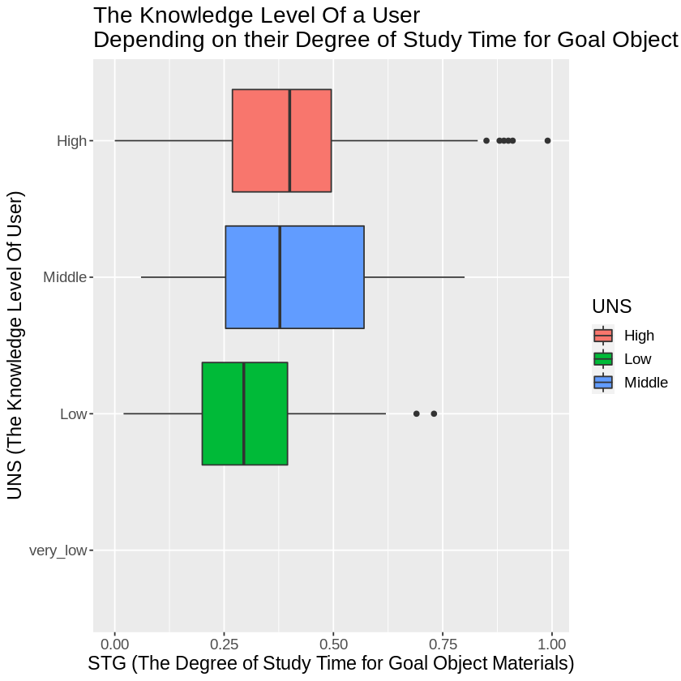

```r
options(repr.plot.width = 7, repr.plot.height = 7)
pvl1
```

Figure 1. Box plot for the knoweldge level of user (UNS) by their degree of study time for goal objects (STG)

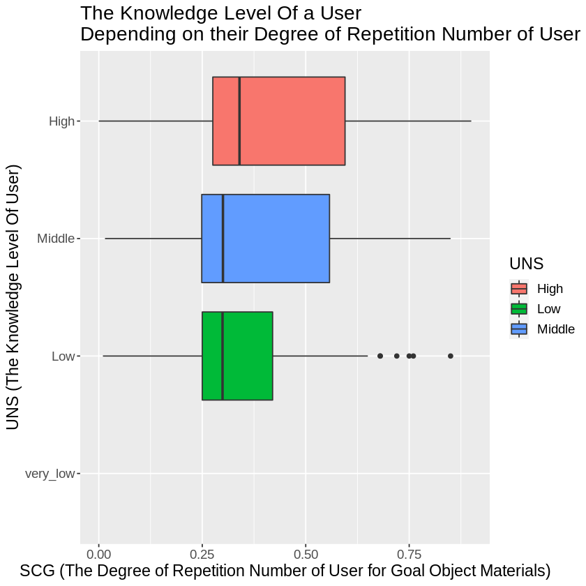

```r
pvl2
```

Figure 2. Box plot for the knoweldge level of user (UNS) by their degree of repetition number of user (SCG)

**Pvl3**: There is no real relationship between UNS and STR.

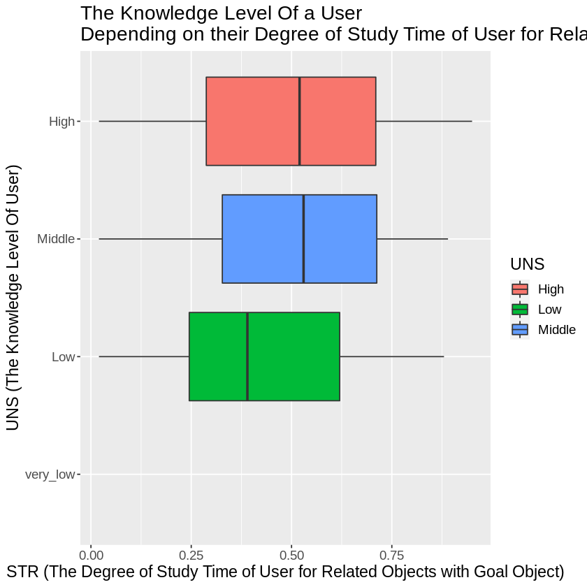

```r
pvl3
```

Figure 3. Box plot for the knoweldge level of user (UNS) by their degree of study of user for related objects with goal object (STR)

**Pvl4**: There is no real relationship between UNS and LPR.

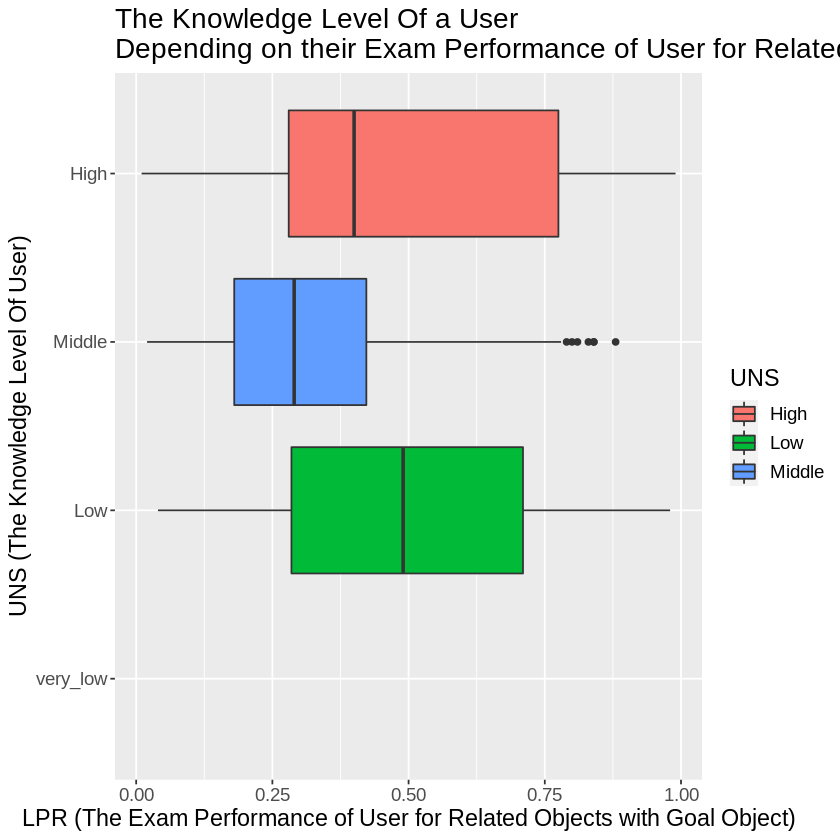

```r
pvl4
```

**Pvl5**: There is a clear positive correlation between the mean of exam performance for Goal Objects and UNS. In other words, the dataset shows that the higher the student can score in their exam, the higher their level of UNS is. There are some outliers where the students scored less than the mean score, but have a higher level of UNS than the majority in their group.

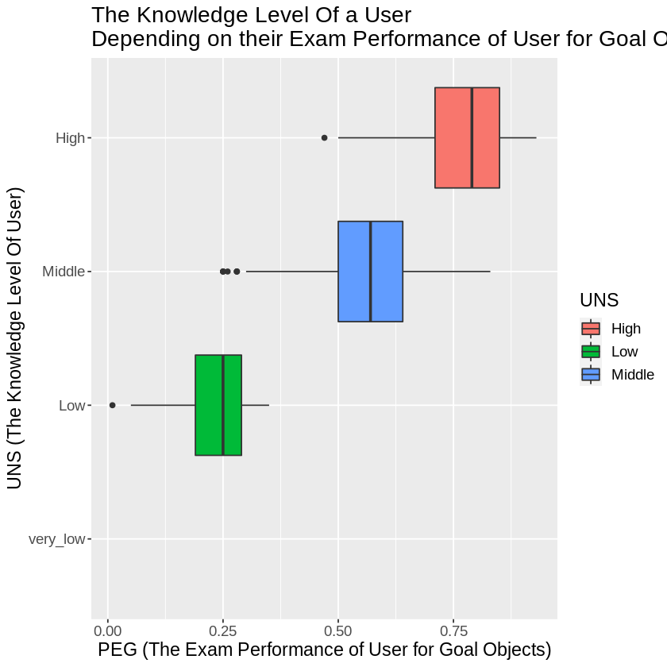

```r
pvl5
```

Figure 5. Box plot for the knoweldge level of user (UNS) by their exam performance of user for goal objects (PEG)

**accuracies:** Using forward selection, test each combination of variables to find which ones are most suitable to use as predictors. As we can see in this table, the combination of PEG + LPR gives the highest estimated accuracy for predicting UNS; therefore it would be ideal to use the PEG and LPR as predictors.

```r
accuracies
```

A tibble: 5 × 3

| size <int> | model_string <chr> | accuracy <dbl> |
| --- | --- | --- |
| 1 | UNS ~ PEG | 0.8453474 |
| 2 | UNS ~ PEG+LPR | 0.9577533 |
| 3 | UNS ~ PEG+LPR+SCG | 0.9307463 |
| 4 | UNS ~ PEG+LPR+SCG+STG | 0.8527378 |
| 5 | UNS ~ PEG+LPR+SCG+STG+STR | 0.7754202 |

**Point:** The categories of UNS are clearly separated into different sections of the graph. We can see that as PEG gets larger, the UNS of the observations increase from Very Low to Low to Middle to High.

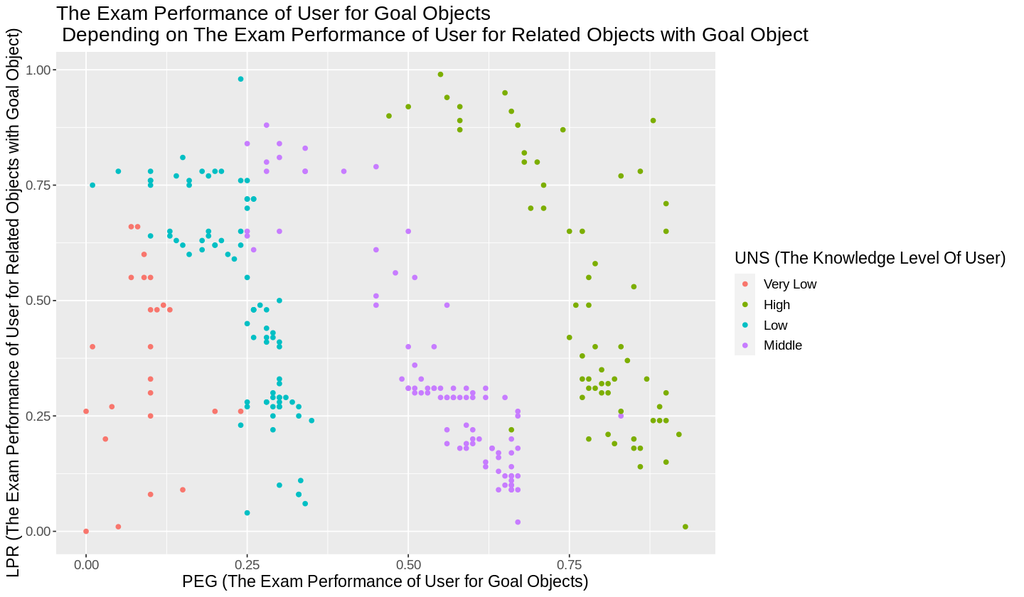

```r
options(repr.plot.width = 12, repr.plot.height = 7)
point
```

### Performing data analysis

The predictor variables we are going to use are PEG and LPR. This is because we used forward selection to try and see which combination of variables is most likely to be accurate for predicting UNS, and PEG + LPR had the highest estimated accuracy, at 0.96. We also graphs PEG against LPR and coloured the observations by UNS, to try and see if the observations are indeed separated into clear categories, which they are.

We first created a recipe with our training data and tuned the number of neighbors using K-NN classification. We then performed a 5-fold cross-validation in order to find the most accurate k-value for our model using the training data. We created a workflow using our recipe and 5-folds to tune the model to choose the most accurate K-values. We used `collect_metrics` to find the accuracy of each classifier and plotted the accuracies on a line plot to get the k-value with the highest estimated accuracy.

```r
set.seed(2022)
knn_spec <- nearest_neighbor(weight_func = "rectangular", neighbors = tune()) |>
      set_engine("kknn") |>
      set_mode("classification")

knn_recipe <- recipe(UNS ~ PEG + LPR, data = user_training_data)

vfold <- vfold_cv(user_training_data, v = 5, strata = UNS)

knn_fit <- workflow() |>
              add_recipe(knn_recipe) |>
              add_model(knn_spec) |>
              tune_grid(resamples = vfold, grid = 10) |>
              collect_metrics() |>
              filter(.metric == "accuracy")

knn_fit_graph <- ggplot(knn_fit, aes(x = neighbors, y = mean)) +
                geom_point() +
                geom_line() +
                labs(x = "Neighbors (K)", y = "Accuracy Estimate") +
                ggtitle("Plotting Accuracy Estimate against Neighbor K") +
                theme(text = element_text(size = 14))
```

A tibble: 10 × 7

[output not shown]

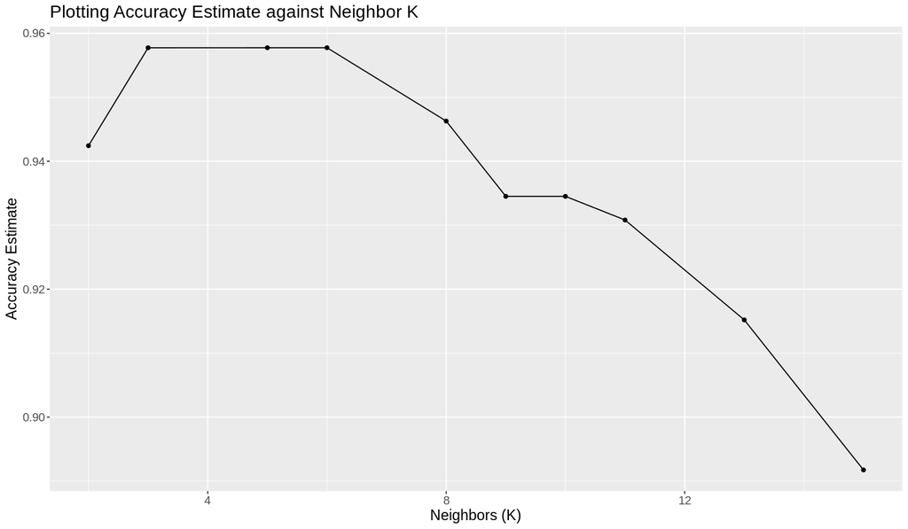

```r
knn_fit_graph
knn_fit <- knn_fit %>%
    arrange(desc(mean))
knn_fit
```

Figure 7. The accuracy estimate of UNS against the K-value

Choosing a higher estimated accuracy gives us a higher chance of creating a more accurate model. As we can see from the accuracy estimate and K-nearest neighbor plot in Figure 7., the K-value of 3, 5, and 6, all have very similarly high accuracy values. However, we chose k = 3, because it is more time efficient to choose a smaller k-value where possible. This is because as the k value increases, the time used for processing also increases.

```r
accuracy <- knn_fit |>
    filter(neighbors == 3) |>
    select(mean)
accuracy
```

A tibble: 1 × 1

| mean <dbl> |
| --- |
| 0.9577505 |

We also want to find the accuracy score for the training set where k = 3. The score is 0.957, which is high. It will be useful to compare the score with the test score later.

After finding the optimal k value, we create a workflow that would predict the data against our testing set. We made a scatter plot of our UNS class predictions to show the distribution of the predicted classes for exam performance, and then we put that side by side with the actual truth values of the testing set for a visual comparison of the model’s accuracy. We also calculated the estimated accuracy of our final model using collect metrics.

```r
knn_spec <- nearest_neighbor(weight_func = "rectangular", neighbors = 3) |>
      set_engine("kknn") |>
      set_mode("classification")

user_fit <- workflow() |>
              add_recipe(knn_recipe) |>
              add_model(knn_spec) |>
              fit(data = user_training_data)

class_prediction <- predict(user_fit, user_test_data) |>
              bind_cols(user_test_data)
```

```r
# Plotting the Predicted UNS
options(repr.plot.width = 15, repr.plot.height = 10)
class_plot <- ggplot(class_prediction, aes(x = PEG, y = LPR, color = as_factor(.pred_class))) +
            geom_point(size = 2) +
            labs(x = "PEG (The Exam Performance of User for Goal Objects)", y = "LPR (The Exam Performance of User for Related Objects with Goal Object)", color = "UNS (The Knowledge Level Of User)")+
            ggtitle("The PREDICTED Exam Performance of User for Goal Objects \n Depending on The Exam Performance of User for Related Objects with Goal Object") +
            theme(text = element_text(size = 14))
```

```r
# Plotting the True UNS
options(repr.plot.width = 15, repr.plot.height = 10)
true_plot <- ggplot(class_prediction, aes(x = PEG, y = LPR, color = as_factor(UNS))) +
            geom_point(size = 2) +
            labs(x = "PEG (The Exam Performance of User for Goal Objects)", y = "LPR (The Exam Performance of User for Related Objects with Goal Object)", color = "UNS (The Knowledge Level Of User)")+
            ggtitle("The Exam Performance of User for Goal Objects \n Depending on The Exam Performance of User for Related Objects with Goal Object") +
            theme(text = element_text(size = 14))
```

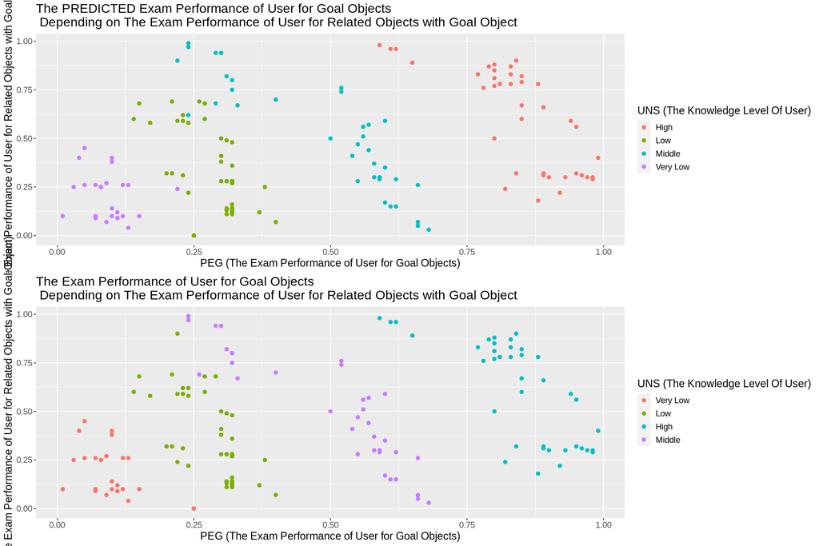

```r
library('cowplot')
library(patchwork)
plot_grid(class_plot, true_plot, ncol = 1)
```

```r
class_accuracy <- class_prediction |>
    mutate(UNS = as.factor(UNS)) |>
    mutate(.pred_class = as.factor(.pred_class)) |>
    metrics(truth = UNS, estimate = .pred_class)

class_accuracy
```

A tibble: 2 × 3

| .metric <chr> | .estimator <chr> | .estimate <dbl> |
| --- | --- | --- |
| accuracy | multiclass | 0.9517241 |
| kap | multiclass | 0.9347686 |

## Disucssion

Additionally, the accuracy score we got on our testing data was 0.951. While this appears to be good, keep in mind that the training score was 0.957, which is slightly higher than what we have for the test set. Normally, if the train and test scores are significantly different, then our model would be considered overfitting or underfitting. However, the difference is very small, thus indicating that our model was successful in accurately predicting UNS. Therefore, we can use it to analyze the relationship between user knowledge and exam performance.

### Impact of findings

These findings will allow for data-based evidence on which method would lead to a better understanding of DC machines. We expect to find that higher levels of PEG and LPR will lead to a better understanding of DC machines, ie: a higher UNS. These findings could have a positive impact on the academic community, as we could let professors know how to better gauge their students’ understanding of a certain topic.

### What's next

Some further questions we can ask are: How should we optimize the students’ exam performance with various Goal Objects? What do we need to improve to better teach students about Electrical DC Machines? What are the best methods students can use to improve their understanding?

## References

H. T. Kahraman, Sagiroglu, S., Colak, I., Developing intuitive knowledge classifier and modeling of users' domain dependent data in web, Knowledge Based Systems, vol. 37, pp. 283-295, 2013.

Kahraman, H. T. (2009). Designing and Application of Web-Based Adaptive Intelligent Education System. Gazi University Ph. D. Thesis, Turkey, 1-156.

Tsiriga, V., Virvou, M. “A Framework for the Initialization of Student Models in Web-based Intelligent Tutoring Systems, User Modeling, and User-Adapted Interaction.” Kluwer Academic Publishers, vol. 14, pp. 289–316, 2004.

Timbers, T., Campbell, T., and Lee, M. “Data Science: A First Introduction.” CRC Press, vol. 1, 2022.